# Ford GoBike Data Exploration

## Bivariate Exploration

> Here, we want to look at correlations between diiferent features in the dataset.

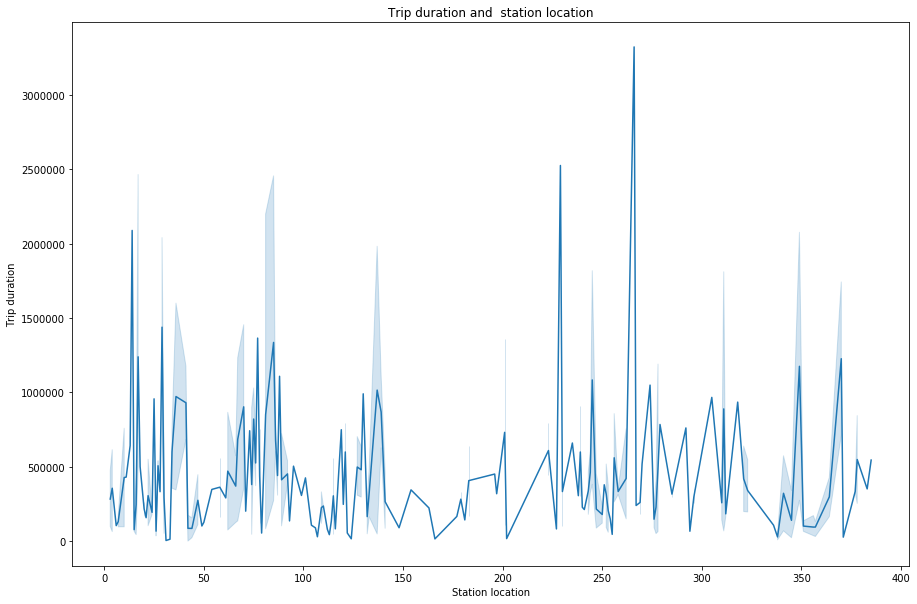

```python
Starting = []

start_stations = sorted(tripdata_copy.start_station_id.unique())
for x in start_stations :
    Starting.append(tripdata_copy[tripdata_copy.start_station_id == x].duration_sec.sum())
total_duration = pd.Series(Starting)

plt.figure(figsize = [15, 10])
sb.lineplot(x = tripdata_copy['start_station_id'], y = total_duration)
plt.title('Trip duration and  station location')
plt.xlabel('Station location')
plt.ylabel('Trip duration')
plt.show()
```

The plot reviews that a longer trip duration occurs in station location between 0 and 50, just before 230 and 270. Some location has a longer trip duration.

We would also check the realtionship between user type and trip duration.

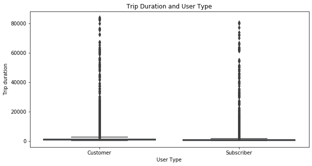

```python
plt.figure(figsize = [10, 5])
base_color = sb.color_palette()[0]
sb.boxplot(data = tripdata_copy, x = 'user_type', y = 'duration_sec', color = base_color)
plt.title('Trip Duration and User Type')
plt.xlabel('User Type')
plt.ylabel('Trip duration')
plt.show()
```

It is difficult to make any observation here, so I will reduce the y-axis limit to get a better obseravtion.

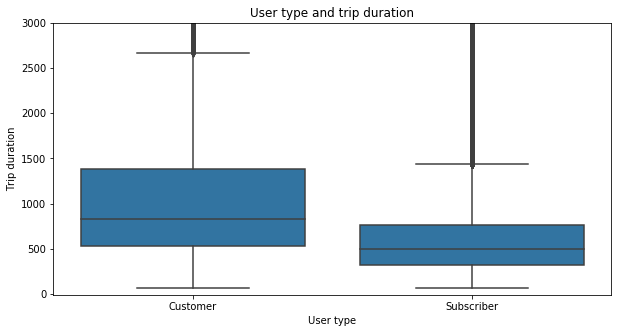

```python
plt.figure(figsize = [10, 5])
base_color = sb.color_palette()[0]
sb.boxplot(data = tripdata_copy, x = 'user_type', y = 'duration_sec', color = base_color)
plt.ylim([-10, 3000])
plt.title('User type and trip duration')
plt.xlabel('User type')
plt.ylabel('Trip duration')
plt.show()
```

It is surprsing to see that more customer has a higer trip duration in contrast to the subscriber. Thus, been a subscriber or customer doesn't have a limit how long an individual can ride.

Let's go ahead and also check the relation between hour of the day and trip duration.

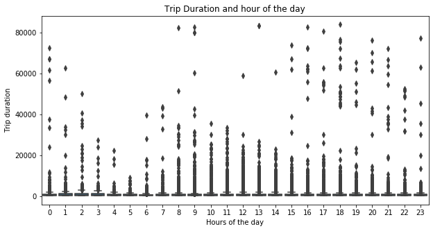

```python
plt.figure(figsize = [10, 5])
base_color = sb.color_palette()[0]
sb.boxplot(data = tripdata_copy, x = 'hours_of_the_day', y = 'duration_sec', color = base_color)
plt.title('Trip Duration and hour of the day')
plt.xlabel('Hours of the day')
plt.ylabel('Trip duration')
plt.show()
```

It is difficult to make any observation here, so I will reduce the y-axis limit to get a better obseravtion.

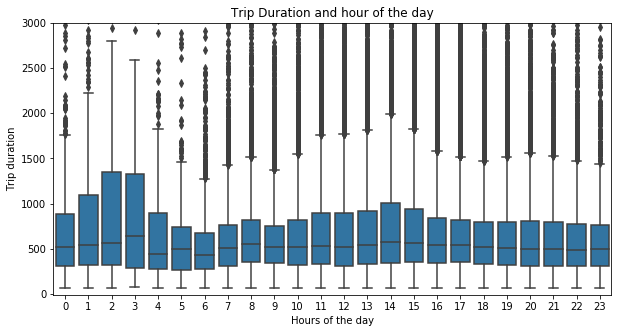

```python
plt.figure(figsize = [10, 5])
base_color = sb.color_palette()[0]
sb.boxplot(data = tripdata_copy, x = 'hours_of_the_day', y = 'duration_sec', color = base_color)
plt.ylim([-10, 3000])
plt.title('Trip Duration and hour of the day')
plt.xlabel('Hours of the day')
plt.ylabel('Trip duration')
plt.show()
```

Here, it is interesting to discover that at 3:00 in the morining there is a higer trip duration, this I guess could be as a result of few avilablle transportation options at that time if the day. Starting from 8:00 in the morning, the trip duration is about 520 seconds on average.

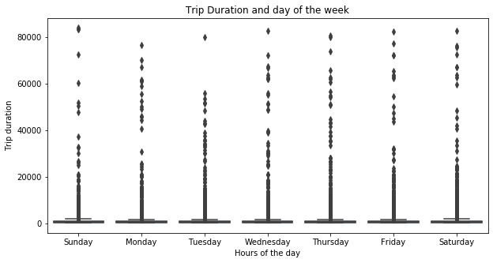

```python
plt.figure(figsize = [10, 5])
base_color = sb.color_palette()[0]
sb.boxplot(data = tripdata_copy, x = 'day_of_the_week', y = 'duration_sec', color = base_color)
plt.title('Trip Duration and day of the week')
plt.xlabel('Hours of the day')
plt.ylabel('Trip duration')
plt.show()
```

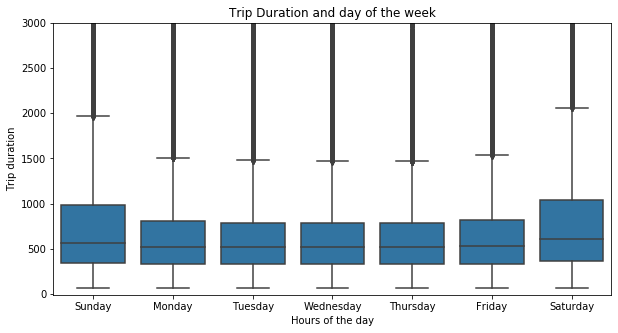

```python
plt.figure(figsize = [10, 5])
base_color = sb.color_palette()[0]
sb.boxplot(data = tripdata_copy, x = 'day_of_the_week', y = 'duration_sec', color = base_color)
plt.ylim([-10, 3000])
plt.title('Trip Duration and day of the week')
plt.xlabel('Hours of the day')
plt.ylabel('Trip duration')
plt.show()
```

This shows that longer trips are taken during the weekends (Sunday and Saturday). This could be because its a free time of everbody.

## Multivariate Exploration

> I will like to explore in this part of the analysis how the two categorical measures day of the week and user type play into the relationship between hours of the day and trip duration.

[output not shown]

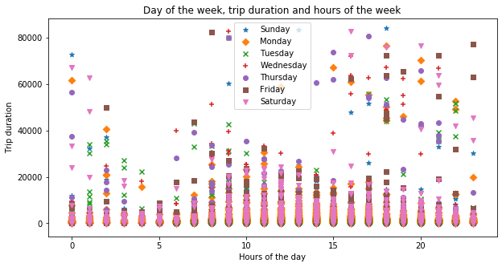

```python
plt.figure(figsize = [10, 5])
categoric_vars = [['Sunday', '*'],['Monday','D'],['Tuesday','x'],['Wednesday','+'],['Thursday', 'o'], ['Friday','s'], ['Saturday','v']]
for day,markers in categoric_vars:
    tripdata_day = tripdata_copy[tripdata_copy['day_of_the_week'] == day]
    plt.scatter((tripdata_day['hours_of_the_day']), tripdata_day['duration_sec'], marker = markers, alpha= 1)


plt.legend(['Sunday','Monday','Tuesday','Wednesday','Thursday', 'Friday', 'Saturday'])
plt.title('Day of the week, trip duration and hours of the week')
plt.xlabel('Hours of the day')
plt.ylabel('Trip duration')
plt.show()
```

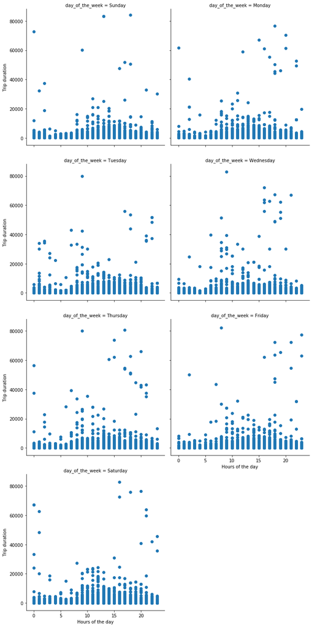

```python
user_type = sb.FacetGrid(data = tripdata_copy, col = 'day_of_the_week', col_wrap = 2, size = 5)
user_type.map(plt.scatter, 'hours_of_the_day', 'duration_sec', alpha= 1)

user_type.set_xlabels('Hours of the day')
user_type.set_ylabels('Trip duration')
plt.show()
```

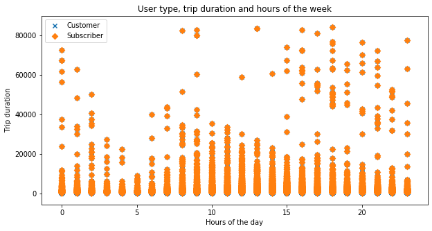

```python
plt.figure(figsize = [10, 5])
categoric_vars =  [['Customer', 'x'],['Subscriber', 'D']]
for user,markers in categoric_vars:
    tripdata_user = tripdata_copy[tripdata_copy['user_type'] == day]
    plt.scatter((tripdata_copy['hours_of_the_day']), tripdata_copy['duration_sec'], marker = markers, alpha= 1)

plt.legend(['Customer','Subscriber'])
plt.title('User type, trip duration and hours of the week')
plt.xlabel('Hours of the day')
plt.ylabel('Trip duration')
plt.show()
```

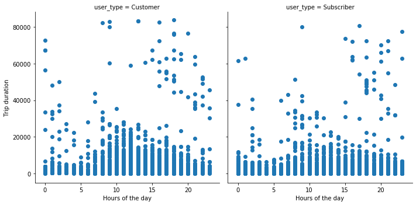

```python
user_type = sb.FacetGrid(data = tripdata_copy, col = 'user_type', col_wrap = 2, size = 5)
user_type.map(plt.scatter, 'hours_of_the_day', 'duration_sec', alpha= 1)

user_type.set_xlabels('Hours of the day')
user_type.set_ylabels('Trip duration')
plt.show()
```

### Were there any interesting or surprising interactions between features?

> Taking a look at this plot, it also attest to our previous observations that customer had a longer trip time than subcribers.